# Wittenberg University - Master of Science in Analytics

ANLT 510

Day 1: Probability & Statistics Review

11 Oct 2021

# Probability and Statistics

## Overview

- Introduce Probability and Statistics Concepts
- Distinguishing between **S**tatistics and **s**tatistics
- Descriptive Statistics vs. Inferential Statistics
- Descriptive Statistics
  - Measures of central tendency
  - Measures of variation
- Generating numeric and visual data summaries

# Definitions

- Probability: the branch of mathematics dealing with calculating the likelihood of an event’s occurrence and the uncertainty involved
- Statistics: the branch of mathematics related to collecting and analyzing numerical data for the purpose of making inferences and/or predictions about a population
- This lecture introduces the relationship between these areas - to accomplish this we’ll need to explore the following concepts:
  - Experiment
  - Outcome
  - Sample space
  - Event
  - Borel Sigma-Algebra
  - Random Variable
  - Statistic

# Probability Concepts

## Experiment

- A scientific procedure undertaken to make a discovery, test a hypothesis, or demonstrate a known fact
  - When you hear the word experiment you may be think of scientists in lab coats or remember your experiences in a Chemistry class
  - While these are accurate representations of an experiment, I’d like for you to think more broadly - think of an experiment simply as a process that generates data that will be used to help make some decision
- From this definition we see that we are surrounded by experiments
  - The time required for a computer to boot up each morning
  - The result of a coin flip
  - The result of rolling a die
- As an analyst, you likely won’t be involved in the experiment - instead, you may be asked to analyze some data that had already been collected
- Understanding the type of data generated by an experiment and the manner in which the data are collected are crucial to selecting a valid approach best to model the data
- For the rest of this lecture we’ll use a simple experiment in which we roll a 6-sided die one or more times

## Outcomes

- An outcome is any result that could possibly be observed from an experiment
  - If our experiment involved a single roll of a 6-sided die, it is trivial to say that the possible outcomes are $\{1\}$, $\{2\}$, $\{3\}$, $\{4\}$, $\{5\}$, or $\{6\}$
  - Similarly we understand that an impossible outcome would be any number that is not an integer and any integer that is either less than zero or greater that 7
  - Note that each outcome is enclosed within curly brackets
- Suppose, an experiment involves rolling a 6-sided die two times, what would some possible outcomes be?
  - Many times the response is “Any number between 2 and 12” - but this is incorrect
  - This response assumes that I want you to take the result of the two rolls and add them together
  - While I may eventually ask you to do this, this is not the same as the possible outcomes
  - some possible outcomes would be $\{1,5\}$, $\{3,1\}$, or $\{6,6\}$. An outcome that would not be possible would be $\{7,2\}$.

## Sample space

- The sample space refers to the collection of all possible outcomes that could result from an experiment
- In the literature the sample space is often denoted by the Greek capital letter omega $\Omega$ or a capital script “S” $\mathcal{S}$

## Events

- An event is a set of outcomes from an experiment (a subset of the sample space) to which a probability can be assigned
- A single outcome may be an element of many different events, and different events in an experiment are usually not equally likely, since they may include very different groups of outcomes

## Random Variable

- Informally, a random variable defined as a variable whose value is random (duh).
- More formally, a random variable is a function that assigns probabilities to events

## Borel Sigma-Algebra

- Represents the mapping of the outcomes to the events

# Statistics Concepts

## Terminology

- Again Statistics is a sub-field of applied mathematics and is concerned with analyzing data
- More specifically, statistics involves the following tasks
  - Collecting Data
  - Organizing Data
  - Displaying and Presenting Data
  - Interpreting Data
- Statistical methods are used to make **descriptions** and/or **inferences** about some population
- It’s not surprising then that statistical methods used in data analyses are often sub-divided into two classes
  - Descriptive statistical methods
  - Inferential statistical methods

## Distinguishing between **S**tatistics and **s**tatistics

- Before moving forward we need to make a clear distinction between **S**tatistics (big S) and **s**tatistics (little s)
  - **S**tatistics (big S) is a sub-field of applied mathematics and is concerned with analyzing data
  - **s**tatistics (little s) are numerical quantities calculated from a data set that provide important features about the data
- In this presentation we define a number of descriptive **s**tatistics (little s)
  - Explain what important features they provide to help us understand our data
  - Show how they are calculated
  - Demonstrate how to compute them using R
- The big idea is that descriptive statistics allow us to reduce large data sets down to a few numerical measures - these measures give clues as to how to proceed in an analysis

# Random Samples

## Defining terms

- The $n$ observations we collect during a test - denoted as $\xi = [x_1,\ldots,x_n]$ - are realizations of random variables $\Xi = [X_1,\ldots,X_n]$
- When a random sample contains $n$ realizations $x_{1},\ldots,x_{n}$ of $n$ random variables $\xi = [x_1,\ldots,x_n]$ we say that the sample has size $n$ (or that the sample size is $n$) and an individual realization $x_{i}$ is referred to as an observation

> Incorrect wording: $n$ independent realizations of the random variable $X$  
> Correct wording: realizations of $n$ independent random variables $X_1,\ldots,X_n$
- In the simplest case the random variables $X_1,\ldots,X_n$ are independent and have a common distribution function $F_{_{X}}(x)$ and we say that $X_1,\ldots,X_n$ are independent and indentically distributed, or IID
- IID Example
  - The lifetime of our widgets is represented by the random variable $X$, whose distribution function $F_{_{X}}(x)$ is unknown.
  - Suppose we independently observe the lifetimes of $10$ widgets and denote these realizations by $x_{1},x_{2},\ldots,x_{10}$
  - We’re interested in the expected value of $X$, which is an unknown characteristic of $F_{_{X}}(x)$
  - We infer $\operatorname{E}[x]$ from the data, and estimate $\operatorname{E}[x]$ with the sample mean $\bar{x} = \sum_{i = 1}^{10} x_i/10$
  - The observed data $x_{1},x_{2},\ldots,x_{10}$ constitute our sample and $\operatorname{E}[x]$ is the quantity about which we are making a statistical inference
- While in the simplest case $X_1,\ldots,X_n$ are independent random variables, more complicated cases are possible
  - $X_1,\ldots,X_n$ are not independent
  - $X_1,\ldots,X_n$ are random vectors having a common joint distribution function
  - $X_1,\ldots,X_n$ do not have a common probability distribution
- In a more general sense we say: *A sample $\xi$ is the realization of a random vector $\Xi$*
- The distribution function of $\Xi$, denoted by $F_{_{\Xi}}(\xi)$, is the unknown distribution function that constitutes the object of inference
- Therefore, “sample” is just a synonym of “realization of a random vector”. The following examples show how this general definition accommodates the special cases mentioned above

## Example 1: Independent and Identically Distributed

- We observe $n$ realizations $x_{1},\ldots,x_{n}$ of $n$ independent random variables $X_1,\ldots,X_n$ having a common distribution function $F_{_{X}}(x)$
- The sample is the $n$-dimensional vector $\xi = [x_1,\ldots,x_n]$, which is a realization of the random vector $\Xi = [X_1,\ldots,X_n]$
- The joint distribution function of $\Xi$ is

$$F_{_{\Xi}}(\xi) = F_{_{X}}(x_1)\times\ldots\times F_{_{X}}(x_n)$$

## Example 2: Identically Distributed, but not Independent

- We observe $n$ realizations $x_{1},\ldots,x_{n}$ of $n$ random variables $X_1,\ldots,X_n$ that are not independent but have a common distribution function $F_{_{X}}(x)$
- The sample is again the $n$-dimensional vector $\xi = [x_1,\ldots,x_n]$, which is a realization of the random vector $\Xi = [X_1,\ldots,X_n]$
- However, in this case the joint distribution function $F_{_{\Xi}}(\xi)$ can no longer be written as the product of the distribution functions of $X_1,\ldots,X_n$

# Descriptive Statistics

## Overview

- Descriptive statistics are numerical measures that help analysts communicate the features of a data set by giving short summaries about the **measures of central tendency** or the **measures of dispersion (variability)**
- Measures of central tendency describe the location of the center of a distribution or a data set
- Some commonly used measures of central tendency are
  - mean
  - median
  - mode
- Measures of variability describe how spread-out the data are
- While measures of central tendency help locate the middle of a data set, they don’t provide information about how the data are arranged (aka distributed)
- Some commonly used measures of variability include:
  - standard deviation
  - variance
  - minimum and maximum values
  - range
  - kurtosis
  - skewness
  - entropy

## Descriptive Statistics vs. Inferential Statistics

- It’s rare that a data set contains observe from every member of a population
  - Most analyses are conducted on a representative sample taken from the population
  - Analysts make inferences about the population based on observations contained in the sample
- Inferential statistics are measures resulting from mathematical computations – help analysts **infer** trends about a population based upon the study of the sample
- Examples of inferential statistics
  - Methods to compute **Confidence intervals** that “capture” a population parameter with a specified degree of confidence
  - Methods to test claims about the population by analyzing a representative samples (**hypothesis tests**)
- In the rest of this presentation we’ll cover several descriptive and inferential statistics concepts and show how to implement them using R
- To do this we’ll need to load several packages

```r
library(tidyverse)
library(patchwork)
```

# Measures of Central Tendency

## Measures of Central Tendency - **mean**

- The `base::mean()` function returns the arithmetic average of a set of numeric values stored in a data object
- For the set of values $x_1,x_2, \ldots, x_N$ the mean is calculated as

$$\hat{\mu} = \bar{x} = \frac{\sum_{i = 1}^{N}x_i}{N} = \frac{x_1 + x_2 + \cdots + x_N}{N}.$$

- The sample mean gives an unbiased estimate of the true population mean
  - When taken on average over all the possible samples, `mean()` converges on the true mean of the entire population
  - If the data are the entire population rather than a sample, then `mean(data)` is equivalent to calculating the true population mean $\mu$.
- The `mean()` function requires a vector of numeric values and returns the mean of these values

```r
num_vec = c(-2,-4,1,2,3,5,7,9)
base::mean(num_vec)
```

```
[1] 2.625
```

- If we try find the mean of a `list` or a `data.frame`, the function returns `NA` and we get a warning

```r
l = list("one" = 1,"two" = 2,"three" = 3)

base::mean(l)
```

```
[1] NA
```

```r
class(mtcars)
```

```
[1] "data.frame"
```

```r
base::mean(mtcars)
```

```
[1] NA
```

- However, we can get around these issues using the “apply” function function family as shown below

```r
# apply FUN to each element in list X
# each element in X must be numeric
base::lapply(X = l, FUN = mean)
```

```
$one
[1] 1

$two
[1] 2

$three
[1] 3
```

```r
base::sapply(X = mtcars, mean)
```

```
       mpg        cyl       disp         hp       drat         wt       qsec
 20.090625   6.187500 230.721875 146.687500   3.596563   3.217250  17.848750
        vs         am       gear       carb
  0.437500   0.406250   3.687500   2.812500
```

```r
## Apply mean to each column
base::apply(X = mtcars, MARGIN = 2, FUN = mean)
```

```
       mpg        cyl       disp         hp       drat         wt       qsec
 20.090625   6.187500 230.721875 146.687500   3.596563   3.217250  17.848750
        vs         am       gear       carb
  0.437500   0.406250   3.687500   2.812500
```

```r
## specialized function for computing means of each column
base::colMeans(mtcars)
```

```
       mpg        cyl       disp         hp       drat         wt       qsec
 20.090625   6.187500 230.721875 146.687500   3.596563   3.217250  17.848750
        vs         am       gear       carb
  0.437500   0.406250   3.687500   2.812500
```

## Measures of Central Tendency - **median**

- The `stats::median()` function returns the middle value of a set of numeric values stored in a data object
- For the set of values $X = x_1,x_2, \ldots, x_N$ the median is calculated as

$${\displaystyle \mathrm {median} (X)={\frac {X_{\lfloor (N+1)\div 2\rfloor }+X_{\lceil (N+1)\div 2\rceil }}{2}}}$$

- where $X$ is an ordered list of numbers, $N$ denotes the length of $X$, and $\lfloor .\rfloor$ and $\lceil .\rceil$ represent the floor and ceiling functions, respectively.
- The median is a preferred measure of central location for skewed distributions and data sets, later show how the median summarizes differently than the mean
- As was shown when introducing the mean, we can compute the median of an array of values by passing the array to the `median()` function.
- Note that because the array contains an even number of elements the median is computed as mean of the two number in the middle - in this case 2 and 3

```r
num_vec = c(-2,-4,1,2,3,5,7,9)
stats::median(num_vec)
```

```
[1] 2.5
```

- When using `base::mean()` on a `list` or a `data.frame` we received a warning - when using `stats::median` we get an error

```r
l = list("one" = 1,"two" = 2,"three" = 3)

stats::median(l)
```

```
Error in sort.int(x, na.last = na.last, decreasing = decreasing, ...): 'x' must be atomic
```

```r
class(mtcars)
```

```
[1] "data.frame"
```

```r
stats::median(mtcars)
```

```
Error in median.default(mtcars): need numeric data
```

- Again we can get around this…

```r
# apply FUN to each element in list X
# each element in X must be numeric
base::lapply(X = l, FUN = median)
```

```
$one
[1] 1

$two
[1] 2

$three
[1] 3
```

```r
base::sapply(X = mtcars, median)
```

```
    mpg     cyl    disp      hp    drat      wt    qsec      vs      am    gear
 19.200   6.000 196.300 123.000   3.695   3.325  17.710   0.000   0.000   4.000
   carb
  2.000
```

```r
## Apply mean to each column
base::apply(X = mtcars, MARGIN = 2, FUN = median)
```

```
    mpg     cyl    disp      hp    drat      wt    qsec      vs      am    gear
 19.200   6.000 196.300 123.000   3.695   3.325  17.710   0.000   0.000   4.000
   carb
  2.000
```

```r
## doesn't exist
base::colMedians(mtcars)
```

```
Error in eval(expr, envir, enclos): object 'colMedians' not found
```

## Measures of Central Tendency - **mode**

- The `mode()` of a vector is the value that is most probable or occurs most often
- There is a `mode()` function in R, but it returns the mode property of an object - not what we want
- However we can create this function as shown below

```r
.mode <- function(x){

  if(!is.null(dim(x))) {

    if(dim(x) > 1L) stop("x must be a vector.\\nYou provided a ", class(x))

  }

  if(!is.numeric(x)) stop("x must be numeric")

  ta = table(x)
  tam = max(ta)

  if(all(ta == tam)) return(NA)

  return(as.numeric(names(ta)[ta == tam]))

}
```

- Note that in the vector `num_vec` defined above there is not a unique mode as each value occurs once - this results in the function returning a value of `NA`

```r
num_vec = c(-2,-4,1,2,3,5,7,9)
.mode(num_vec)
```

```
[1] NA
```

- We can then apply this function to a `list` or a `data.frame`

```r
apply(mtcars, 2, .mode)
```

```
$mpg
[1] 10.4 15.2 19.2 21.0 21.4 22.8 30.4

$cyl
[1] 8

$disp
[1] 275.8

$hp
[1] 110 175 180

$drat
[1] 3.07 3.92

$wt
[1] 3.44

$qsec
[1] 17.02 18.90

$vs
[1] 0

$am
[1] 0

$gear
[1] 3

$carb
[1] 2 4
```

# Measures of Variation

## Measures of variation - **range**

- The range of a data set shows the span of the data
- For a sample of observations $X = x_1, x_2,\ldots,x_N$ the range of $X$ may be found from a simple computation

$$\text{range(X)}=\max{(X)} - \min{(X)}$$

- Note - the value of the range statistic is determined by only two observations from any data set - and is easily influenced by the presence of outliers
- In R the range statistic may be computed using the intrinsic functions `range()` or combining `max()` and `min()`

```r
range(num_vec)
```

```
[1] -4  9
```

```r
max(num_vec) - min(num_vec)
```

```
[1] 13
```

## Measures of variation - **variance**

- The variance of a data set measures how far the values are spread out from their average value (or mean)
- For a sample of observations $X = x_1, x_2,\ldots,x_N$ the unbiased sample variance, denoted as $s^2$ is computed as

$${\displaystyle s^{2}={\frac {1}{N-1}}\sum _{i=1}^{N}\left(x_{i}-{\overline {x}}\right)^{2}}$$

- If the data are the entire population the the population variance, denoted as $\sigma^2$ or $\operatorname{Var}[X]$ is computed

$$\sigma^2 = \operatorname {Var}(X)={\frac {1}{N}}\sum _{i=1}^{N}(x_{i}-\mu)^{2}$$

```r
var(num_vec)
```

```
[1] 19.125
```

## Measures of variation - **standard deviation**

- The standard deviation of a data set, like the variance, is measure of how far the values are spread out relative to the mean
- A useful property of the standard deviation is that, unlike the variance, it is expressed in the same units as the data
- If the data are a sample the sample standard deviation, denoted by $s$ is the square root of the sample variance

$$s = \sqrt{s^2} = \sqrt{{\frac {1}{N-1}}\sum _{i=1}^{N}\left(x_{i}-{\overline {x}}\right)^{2}}$$

- If the data are the population the standard deviation, denoted by $\sigma$ is the square root of the variance

$$\sigma = \sqrt{\sigma^2} = \sqrt{\operatorname {Var}(X)}=\sqrt{{\frac {1}{N}}\sum _{i=1}^{N}(x_{i}-\mu)^{2}}$$

- In R the standard deviation of an array of numeric values can be computed using the `stats::sd()` function

```r
sd(num_vec)
```

```
[1] 4.373214
```

# Generating numeric and visual data summaries

```r
N_obs = 4000

normal = rnorm(N_obs, mean = 1, sd = 10000)

lognormal = rlnorm(N_obs, meanlog = 10, sdlog = .75)
```

- Next, I create two-column `data.frame` for the `'normal'` data and a two-column `data.frame` for the `'lognormal'` data

```r
DF.n = data.frame(distribution = 'normal',
                  data = normal)

DF.l = data.frame(distribution = 'lognormal',
                  data = lognormal)
```

- Finally, I merge these objects

```r
DF = merge(DF.n, DF.l, all = T)

head(DF)
```

```
  distribution     data
1    lognormal 2113.888
2    lognormal 2269.430
3    lognormal 2282.725
4    lognormal 2391.058
5    lognormal 2597.675
6    lognormal 2628.042
```

## Histogram of normal and lognormal observations

- This code creates a histogram for the normal data showing that mean and median are nearly the same for symmetrically distributed data (i.e. have low skewness values)

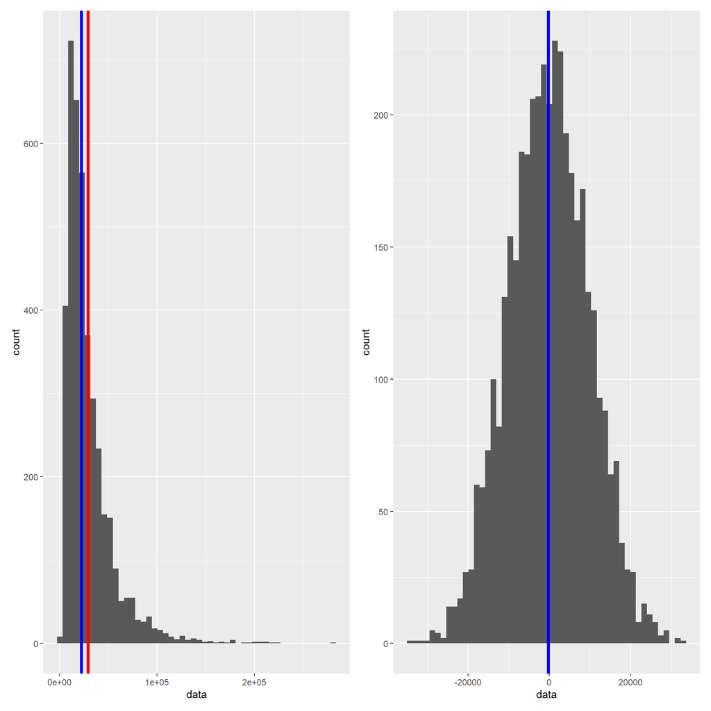

```r
# Settings
p1 = ggplot(DF.l, aes(x = data)) +
  geom_histogram(bins = 50) +
  geom_vline(xintercept = mean(DF.l$data), col = "red", size = 1.5) +
  geom_vline(xintercept = median(DF.l$data), col = "blue", size = 1.5)

p2 = ggplot(DF.n, aes(x = data)) +
  geom_histogram(bins = 50) +
  geom_vline(xintercept = mean(DF.n$data), col = "red", size = 1.5) +
  geom_vline(xintercept = median(DF.n$data), col = "blue", size = 1.5)

p1 + p2
```

## Density plot of normal and lognormal observations

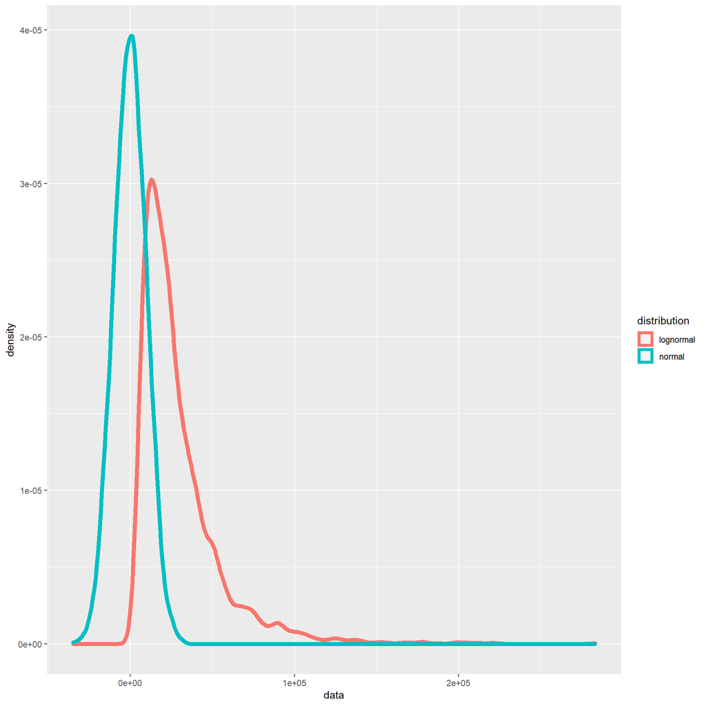

```r
ggplot(DF, aes(x = data, col = distribution)) +
  geom_density(size = 2)
```

## Histogram of lognormal observations

- This code creates a histogram for the lognormal data and shows how the mean and median separate when the data are not symmetrically distributed (i.e. have larger skewness values)

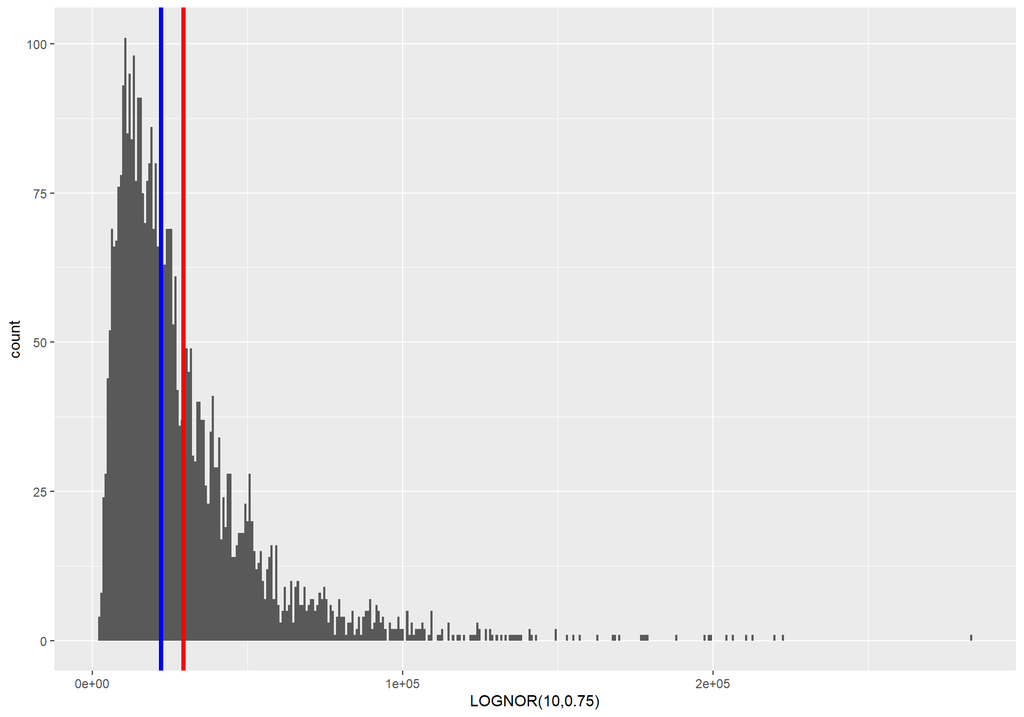

```r
# Create histogram
.data = subset(DF, distribution == 'lognormal', select = data)

ggplot(.data, aes(x = data)) +
  geom_histogram(bins = as.integer(N_obs / 10)) +
  xlab("LOGNOR(10,0.75)") +
  geom_vline(xintercept = mean(.data$data),col = "red", size = 1.5) +
  geom_vline(xintercept = median(.data$data), col = "blue", size = 1.5)
```

## Box plots

- A box plot (or box-and-whisker plot) shows the distribution of quantitative data in a way that facilitates comparisons between variables or across levels of a categorical variable.
- The box shows the quartiles of the data set while the whiskers extend to show the rest of the distribution, except for points that are determined to be “outliers” using a method that is a function of the inter-quartile range.
- The code below generates a boxplot displaying both columns of the `data.frame`

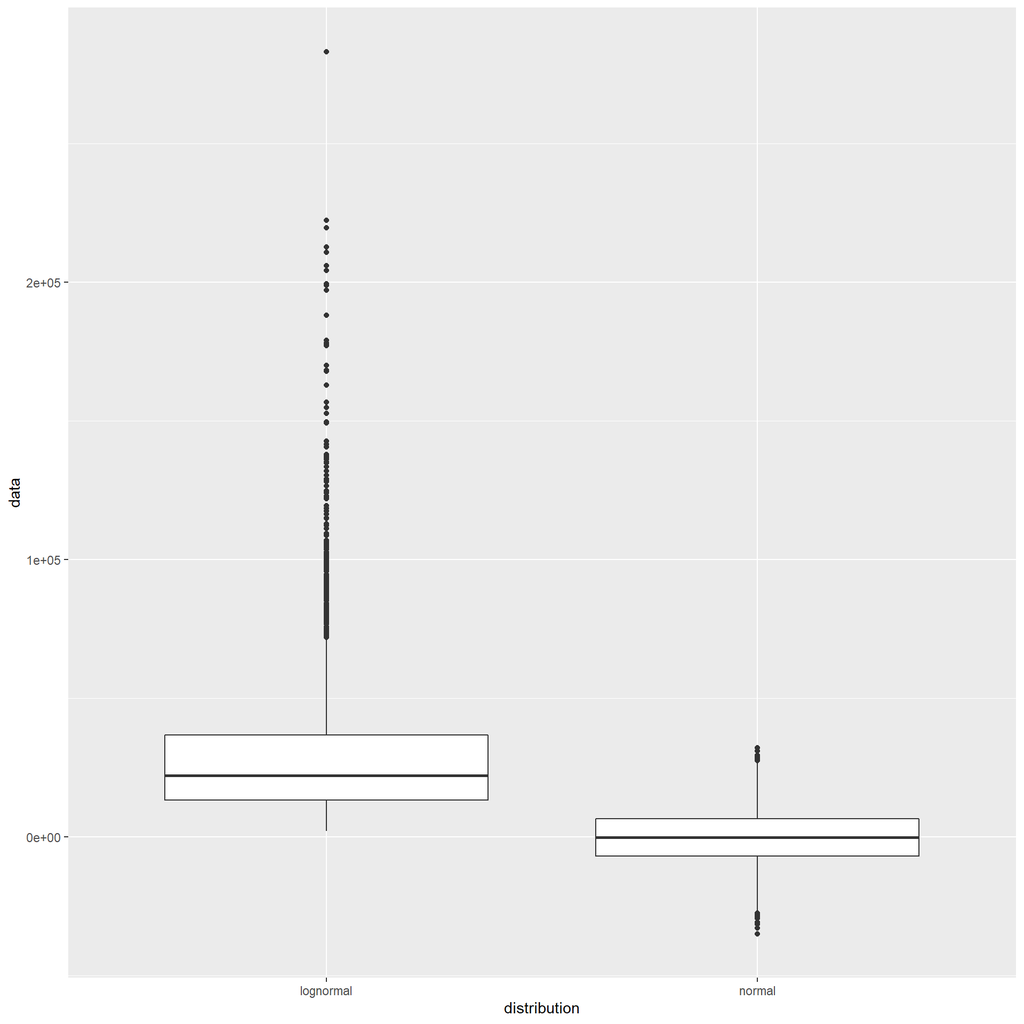

Boxplot comparing the normal and lognormal data

```r
ggplot(DF, aes(x = distribution, y = data))+
  geom_boxplot()
```

## Violin Plots

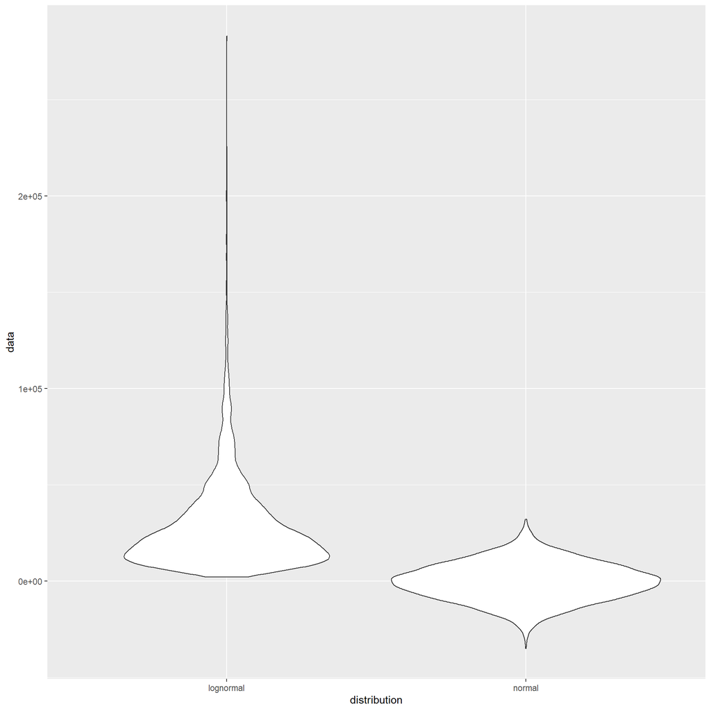

```r
ggplot(DF, aes(x = distribution, y = data))+
  geom_violin()
```

## Covariance

- **Covariance** is a descriptive statistic used to measure the linear association between two variables
- The sample covariance between variables $X$ and $Y$ is computed as

$$S_{XY} = \frac{\sum_{i=1}^N(x_i - \bar{x})(y_i - \bar{y})}{N-1}$$

- The population covariance is computed as

$$\sigma_{XY} = \frac{\sum_{i=1}^N(x_i - \mu_x)(y_i - \mu_y)}{N}$$

- To compute the covariances for the `data.frame`, `DF` we created earlier we can use the `cov()` function from the `stats` library

```r
(cov1 = cov(DF.l$data, DF.n$data))
```

```
[1] -2859695
```

## Correlation

- **Correlation** is a descriptive statistic used to measure the linear association between two variables
- The correlation (or correlation coefficient) is a measure defined between -1 and 1
- Is a dimensionless quantity that is not affected by the units of measurement for X and Y
- The sample correlation between variables $X$ and $Y$ is computed as

$$r_{_{XY}} = \frac{S_{_{XY}}}{s_{_{X}}s_{_{Y}}}$$

- To compute the correlations for the `data.frame`. `DF` we created earlier we can use the `cor()` function from the stats library

```r
stats::cor(DF.n$data, DF.l$data)
```

```
[1] -0.01149661
```

## Covariance and Correlation

- Finally, what if we wanted to compute the covariance ourselves?
- The code below computes the covariance as well as the difference between this value and the value found from using the `cov()` function from `stats`

```r
X = DF.n$data
Y = DF.l$data
X_diff = X - base::mean(X)
Y_diff = Y - base::mean(Y)
prod = X_diff * Y_diff

cov2 = sum(prod) / (length(X) - 1)

cov1 - cov2
```

```
[1] -4.656613e-10
```

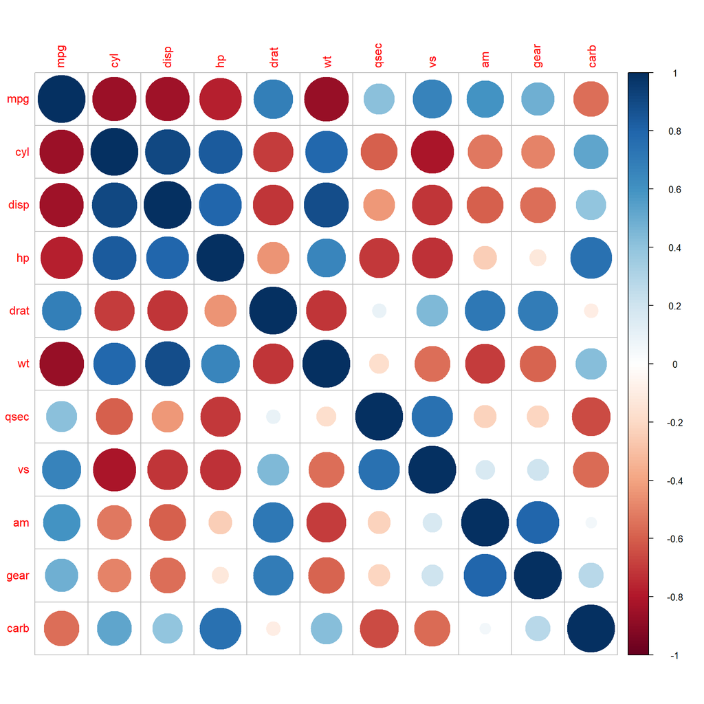

```r
m = cor(mtcars)
corrplot::corrplot(m)
```

# Constructing confidence intervals

## Overview

- Let $X_1, X_2, X_3,\ldots, X_n$ be a random sample from a distribution with a parameter $\theta$ that is to be estimated
- An interval estimator with confidence level $1−\alpha$ consists of two estimators
  - A low estimator $\hat{\Theta}_l=\hat{\Theta}_l(X_1, X_2, \cdots, X_n)$
  - A high estimator $\hat{\Theta}_h=\hat{\Theta}_h(X_1, X_2, \cdots, X_n)$
- Such that for every possible value of $\theta$

$$P\bigg(\hat{\Theta}_l < \theta \, \textrm{and} \, \hat{\Theta}_h > \theta \bigg) \geq 0.95$$

## Finding Intervals Estimators

- Let $X$ be a continuous random variable with CDF $F_X(x)=P(X\leq x)$
- Suppose that we are interested in finding two values $x_h$ and $x_l$ such that

$$P\bigg(x_l \leq X \leq x_h \bigg)= 1-\alpha.$$

- One way to do this, is to find values of $x_l$ and $x_h$ for which

$$\begin{aligned}
P\big(X \leq x_l \big)= \frac{\alpha}{2}, \quad &\textrm{and} \quad P\big(X \geq x_h\big)= \frac{\alpha}{2}\\\\
&\text{or}\\\\
F_X(x_l)=\frac{\alpha}{2}, \quad &\textrm{and} \quad F_X(x_h)= 1-\frac{\alpha}{2}
\end{aligned}$$

- We can rewrite these equations by using the inverse CDF $F^{−1}_X$ as

$$x_l= F^{-1}_X\left(\frac{\alpha}{2}\right), \quad \textrm{and} \quad x_h= F^{-1}_X\left(1-\frac{\alpha}{2}\right).$$

- We call the interval $[x_l,x_h]$ a $(1−\alpha)$ interval for $X$
- A general approach is to start with a point estimator $\hat{\theta}$ and create the interval $\left[\hat{\theta}_l,\hat{\theta}_h\right]$ around it such that $P\bigg(\theta \in \big[\hat{\Theta}_l,\hat{\Theta}_h\big] \bigg) \geq 1-\alpha$

### Confidence interval for $\mu$ - Normally distributed sample

- Let $X_1, X_2, X_3,\ldots, X_n$ be a random sample from a normal distribution $NOR(\theta,1)$ - find a $95\%$ confidence interval for $\theta$

```r
# Number observations
N = 100

# choose level alpha
alpha = 0.05

# parameters
.mean = 5.42
.sd = 1

# Generate random samples
obs = rnorm(N, mean = .mean, sd = .sd)
```

- Start with $\hat{\theta}$, the point estimator for $\theta$
- Since $\theta$ is the mean of the distribution, the point estimator we start with is the sample mean

$$\hat{\theta}=\overline{X}_n=\frac{X_1+X_2+...+X_n}{n}.$$

- Since $X_i \sim NOR(\theta,1)$ and the $X_i$’s are independent, we conclude that

$$\overline{X}_n \sim N\left(\theta, \frac{1}{n}\right).$$

- By normalizing $\bar{X}_n$, we arrive at that the following random variable having a $NOR(0,1)$ distribution

$$\frac{\overline{X}_n-\theta}{\frac{1}{\sqrt{n}}}=\sqrt{n}(\overline{X}_n-\theta)$$

- Thus, for a $100(1-\alpha\%)$ confidence interval we have

$$P\bigg(-z_{(1-\alpha/2)} \leq \sqrt{n}(\overline{X}_n-\theta) \leq z_{(1-\alpha/2)} \bigg)=1-\alpha$$

- By rearranging the terms we have

$$P\bigg(\overline{X}_n-\frac{z_{(1-\alpha/2)}}{\sqrt{n}}\; \leq \;\theta\; \leq \; \overline{X}_n+\frac{z_{(1-\alpha/2)}}{\sqrt{n}}\bigg)=1-\alpha$$

- Therefore, the $100(1-\alpha)\%$ confidence interval for $\theta$ interval is

$$[\hat{\theta}_l, \hat{\theta}_h] =\left[\overline{X}_n-\frac{z_{(1-\alpha/2)}}{\sqrt{n}}, \overline{X}_n+\frac{z_{(1-\alpha/2)}}{\sqrt{n}}\right]$$

```r
# Find z value at alpha / 2
z = qnorm(1-alpha / 2, mean = 0, sd = 1)

( theta_l = mean(obs) - z / sqrt(N) )
```

```
[1] 5.17588
```

```r
( theta_h = mean(obs) + z / sqrt(N) )
```

```
[1] 5.567873
```

# Confidence Intervals for the Variance of Normal Random Variables

## Pivotal quantities

- The crucial fact about the previous example is the random variable $Q = \sqrt{n}(\bar{X}−\theta)$
- The random variable $Q$ is known as a pivotal quantity or simply a pivot
  - A pivot is a function of the observed data $X_1, X_2, X_3, \ldots, X_n$ and the unknown parameter $\theta$, but it does not depend on any other unknown parameters
  - The distribution of $Q$ does not depend on $\theta$ or any other unknown parameters
- To construct a confidence interval one is required to first find a pivotal quantity and its distribution

## Confidence interval for $\sigma^2$

- Suppose that we observe a random sample $X_1, X_2, X_3,\ldots, X_n$
- Further suppose that the observations in teh sample follow a normal distribution for which the mean $\mu$ and the variance $\sigma^2$ are both unknown
- Using the sample we are tasked with constructing an interval estimator for the variance $\sigma^2$
- In this scenario our pivotal quantity is

$$Q=\frac{(n-1)S^2}{\sigma^2}=\frac{1}{\sigma^2}\sum_{i=1}^{n} (X_i-\overline{X})^2$$

- This is a pivotal quantity because $Q$ is a function of the data and of the unknown parameter $\sigma$, but is not a function of the unknown mean $\mu$
- It can be shown that $Q$ follows a [chi-square distribution](https://stattrek.com/probability-distributions/chi-square.aspx) with $n-1$ degrees of freedom
- Thus a $100(1-\alpha\%)$ confidence interval can be constructed as

$$\begin{aligned}
P\left(\chi^2_{1-\frac{\alpha}{2},n-1} \leq Q \leq \chi^2_{\frac{\alpha}{2},n-1} \right)&= 1-\alpha\\\\
P\left(\chi^2_{1-\frac{\alpha}{2},n-1} \leq \frac{(n-1)S^2}{\sigma^2} \leq \chi^2_{\frac{\alpha}{2},n-1} \right)&= 1-\alpha\\\\
P\left(\frac{(n-1)S^2}{\chi^2_{\frac{\alpha}{2},n-1}} \leq \sigma^2 \leq \frac{(n-1)S^2}{\chi^2_{1-\frac{\alpha}{2},n-1}} \right)&= 1-\alpha
\end{aligned}$$

- Therefore, we conclude that a $(1−\alpha)100\%$ confidence interval for $\sigma^2$ is expressed as

$$\left[\frac{(n-1)S^2}{\chi^2_{\frac{\alpha}{2},n-1}} , \frac{(n-1)S^2}{\chi^2_{1-\frac{\alpha}{2},n-1}} \right]$$

### Confidence interval for $\sigma^2$ - Normally distributed sample

```r
# Number observations
N = 100

# choose level alpha
alpha = 0.05

# parameters
.mean = 5.42
.sd = 1

# Generate random samples
obs = rnorm(N, mean = .mean, sd = .sd)
```

```r
S_2 = var(obs)


( sigma_l = ((N-1) * S_2) / qchisq(1-alpha/2,N-1) )
```

```
[1] 0.7927538
```

```r
( sigma_h = ((N-1) * S_2) / qchisq(alpha/2,N-1) )
```

```
[1] 1.387752
```

# Point estimators for the mean (IID, Normally distributed)

## Overview

- The random sample is composed of observations $x_{1},\ldots,x_{n}$ drawn from $n$ independent random variables $X_1,\ldots,X_n$ each of which are normally distributed and having unknown mean $\mu$ and unknown variance $\sigma^2$
- In this scenario an estimator for the population mean $\mu$ is the sample mean

$$\bar{X}_n = \frac{1}{n}\sum_{i=1}^n X_i$$

## Properties of the estimator

- As shown below, the expected value of this estimator is equal to the population parameter $\mu$, therefore the estimator is unbiased

$$\begin{aligned}
\operatorname{E}[\bar{X}_n] &= \operatorname{E}\bigg[\frac{1}{n}\sum_{i=1}^n X_i\bigg]\\
&=\frac{1}{n}\sum_{i=1}^n \operatorname{E}[X_i]\\
&=\frac{1}{n}\sum_{i=1}^n \mu\\
&=\frac{1}{n}n \mu\\
&=\mu
\end{aligned}$$

- Our sequence of random variables (IID with finite mean) satisfies the conditions of [Kolmogorov’s Strong Law of Large Numbers](http://mathworld.wolfram.com/StrongLawofLargeNumbers.html)
- Therefore, the sample mean $\bar{X}_n$ converges [almost surely](https://math.stackexchange.com/questions/1443015/why-do-we-say-almost-surely-in-probability-theory) to the true mean $\mu$ and is strongly consistent
- Convergence of the the sample mean estimator to the population mean

```r
.mean = 5.43
.sd   = 2.65

normal5       = rnorm(5, mean = .mean, sd = .sd)
normal10      = rnorm(10, mean = .mean, sd = .sd)
normal50      = rnorm(50, mean = .mean, sd = .sd)
normal100     = rnorm(100, mean = .mean, sd = .sd)
normal500     = rnorm(500, mean = .mean, sd = .sd)
normal1000    = rnorm(100, mean = .mean, sd = .sd)
normal5000    = rnorm(5000, mean = .mean, sd = .sd)
normal10000   = rnorm(10000, mean = .mean, sd = .sd)
normal50000   = rnorm(50000, mean = .mean, sd = .sd)
normal100000  = rnorm(100000, mean = .mean, sd = .sd)
normal500000  = rnorm(500000, mean = .mean, sd = .sd)
normal1000000 = rnorm(1000000, mean = .mean, sd = .sd)
```

```r
means = data.frame(mean(normal5),
                   mean(normal10),
                   mean(normal50),
                   mean(normal100),
                   mean(normal500),
                   mean(normal1000),
                   mean(normal5000),
                   mean(normal10000),
                   mean(normal50000),
                   mean(normal100000),
                   mean(normal500000),
                   mean(normal1000000))

rownames(means) <- c("Mean")
colnames(means) <- c("      5 obs = ",
                     "     10 obs = ",
                     "     50 obs = ",
                     "    100 obs = ",
                     "    500 obs = ",
                     "   1000 obs = ",
                     "   5000 obs = ",
                     "  10000 obs = ",
                     "  50000 obs = ",
                     " 100000 obs = ",
                     " 500000 obs = ",
                     "1000000 obs = ")
t(means)
```

```
                   Mean
      5 obs =  6.924232
     10 obs =  5.805289
     50 obs =  5.381661
    100 obs =  4.930603
    500 obs =  5.508107
   1000 obs =  5.592977
   5000 obs =  5.431959
  10000 obs =  5.453600
  50000 obs =  5.434774
 100000 obs =  5.443487
 500000 obs =  5.427129
1000000 obs =  5.428567
```

- The variance of the estimator $\bar{X}_n$ is equal to $\sigma^{2}/n$
- This can be shown by applying the variance operator and noting that the obervations are independent

$$\begin{aligned}
\operatorname{Var}[\bar{X}_n] &= \operatorname{Var}\bigg[\frac{1}{n}\sum_{i=1}^n X_i\bigg]\\
&=\frac{1}{n^2}\operatorname{Var}\bigg[\sum_{i=1}^n X_i\bigg]\\
&=\frac{1}{n^2}\sum_{i=1}^n \operatorname{Var}[X_i]\\
&=\frac{1}{n^2}\sum_{i=1}^n \sigma^2\\
&=\frac{1}{n^2}n \sigma^2\\
&=\frac{\sigma^2}{n}
\end{aligned}$$

```r
Vars = data.frame(var(normal5),
                  var(normal10),
                  var(normal50),
                  var(normal100),
                  var(normal500),
                  var(normal1000),
                  var(normal5000),
                  var(normal10000),
                  var(normal50000),
                  var(normal100000),
                  var(normal500000),
                  var(normal1000000))

rownames(Vars) = c("Variance")
colnames(Vars) = c("      5 obs = ",
                   "     10 obs = ",
                   "     50 obs = ",
                   "    100 obs = ",
                   "    500 obs = ",
                   "   1000 obs = ",
                   "   5000 obs = ",
                   "  10000 obs = ",
                   "  50000 obs = ",
                   " 100000 obs = ",
                   " 500000 obs = ",
                   "1000000 obs = ")
t(Vars)
```

```
               Variance
      5 obs =  9.189511
     10 obs =  3.030007
     50 obs =  5.638253
    100 obs =  8.176651
    500 obs =  6.544835
   1000 obs =  6.314301
   5000 obs =  7.112407
  10000 obs =  7.063310
  50000 obs =  7.045719
 100000 obs =  7.026340
 500000 obs =  7.011993
1000000 obs =  7.026339
```

- Using the results obtained above for the expected value and the variance of the estimator, it can be shown that the distribution of the estimator is

$$\bar{X}_n \sim \operatorname{NOR}(\mu,\sigma^2/n)$$

# Point estimators for the mean - (IID, not normally distributed)

## Overview

- The sample $x_{1},\ldots, x_{n}$ is composed of realizations drawn from $n$ independent random variables $X_1,\ldots, X_n$, all having the same distribution with unknown mean $\mu$ and variance $\sigma^2$
- As was shown above for the case when the random variables are all normally distributed, the estimator of the population mean $\mu$ is the sample mean

$$\bar{X}_n = \frac{1}{n}\sum_{i=1}^n X_i$$

## Properties of the estimator

```r
norm_converge <- function(samp_siz, num_sims, exp = TRUE, param = 0.3){

    mean_vec = double(num_sims)

    for(i in 1:length(num_sims)){

      `if`(exp == TRUE,
           samp <- rexp(samp_siz, rate = 1/param),
           samp <- rweibull(samp_siz, shape = 1.5, scale = 1/param))

      mean_vec[i] = mean(samp)

      }

    ggplot(data.frame(mean = mean_vec), aes(x = mean_vec)) +
      geom_density()


    }
```

- With the function defined run the code shown below to view the effect of changing the variables

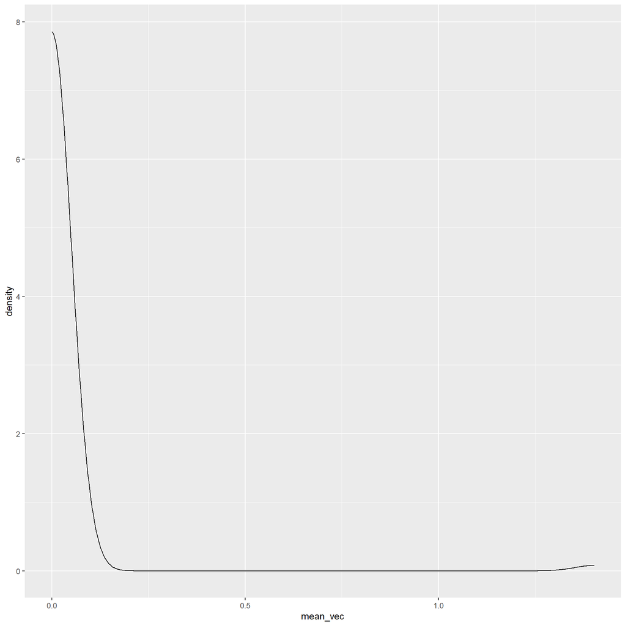

```r
norm_converge(samp_siz = 3, num_sims = 100, exp = !TRUE, param = 0.4)
```

# Point estimators for the variance (IID, Normally distributed, known mean)

## Overview

- The random sample $x_{1},\ldots,x_{n}$ is composed of realizations drawn from $n$ independent random variables $X_1,\ldots, X_n$, all of which are normally distributed with known mean $\mu$ and unknown variance $\sigma^2$
- Assuming that the variance is positive and finite $(0<\sigma^2<\infty)$, then by definition

$$\sigma^2=\operatorname{E}\Big[\big(X−\mu\big)^2\Big].$$

- Therefore, the variance is the mean of the random variable

$$Y = \big(X−\mu\big)^2.$$

- Which implies the following estimator for the variance, denoted by $S^2$

$$S^2 = \widehat{\sigma}^2 =\frac{1}{n}\sum_{i=1}^n\big(X_i−\mu\big)^2.$$

## Properties of the estimator

- Because of the linearity of the expectation operator it can be shown that $\overline{S}^2$ is an unbiased estimator of $\sigma^2$ if the value of the mean is known.
- However, We typically don’t know the value of $\mu$ - so we replace $\mu$ with its estimator, the sample mean, to obtain the following estimator for $\sigma^2$

$$S^2=\frac{1}{n}\sum_{i = 1}^n(X_i−\overline{X})^2$$

- After expanding the squared term and applying some algebra, we have the following estimator for the variance based on the sample mean

$$S^2=\frac{1}{n}\sum_{i = 1}^n(X^2_i−\overline{X}^2).$$

- We can determine whether this is an biased estimator for the variance as follows

$$\begin{aligned}
\operatorname{Bias}\big(S^2\big) &= \operatorname{E}\big[S^2\big]-\sigma^2\\
&=\frac{1}{n} \left(\sum_{i=1}^n E\big[X_i\big]^2-nE\big[\overline{X}^2\big]\right) - \sigma^2\\
&=\frac{1}{n} \left(n(\mu^2+\sigma^2)-n\left(\mu^2+\frac{\sigma^2}{n}\right)\right)-\sigma^2\\
&=\frac{n-1}{n}\sigma^2-\sigma^2\\
&=-\frac{\sigma^2}{n}
\end{aligned}$$

- Thus, we see that $\overline{S}^2$ is a biased estimator for the variance because it includes the $(n-1)/n$ term
- We can eliminate this term by multiplying $S^2$ by the reciprocal of this term $n/(n-1)$
- We know that including this term will cancel out the $(n-1)/n$ term in the end
- The result is an estimator known as adjusted sample variance $s^2$ which is an unbiased estimator for the variance

$$s^2=\frac{1}{n-1}\sum_{i = 1}^n(X_i−\overline{X})^2.$$

- The variance of the adjusted sample variance is expressed as shown below

$$\operatorname{Var}\left[s^2\right] = \frac{2\sigma^2}{n-1}$$

- While not done here, it can be shown that this estimator has a gamma distribution with parameters $n$, and $\sigma^2$

# Hypothesis testing

## General setup

- In hypothesis testing we use a random sample to decide between two contradictory hypotheses
  - Let $S$ be the set of possible values for an unknown parameter $\theta$
  - Suppose we can partition $S$ into two disjoint sets $S_0$ and $S_1$
  - Let $H_0$ be the hypothesis that $\theta\in S_0$, and let $H_1$ be the hypothesis that $\theta\in S_1$
- To decide whether to choose $H_0$ or $H_1$, we use a test statistic, denoted by $W$ where $W=W(X_1,X_2,\ldots,X_n)$
  - Assuming $H_0$, we can define the set $A$ as the set of possible values of $W$ for which we would accept $H_0$
  - The set $A$ is called the acceptance region, while the set $R=S−A$ is said to be the rejection region

# Hypothesis testing for the mean

- Assume we have a random sample $X_1,X_2,\ldots,X_n$ from a distribution
- Our goal is to make an inference about the mean of the distribution $\mu$ - we can consider three distinct testing scenarios

$$\begin{aligned}
\text{Case 1: } &\text{A two-sided test}\\
&H_O \text{ is a simple hypothesis and } H_1 \text{ is a two-sided hypothesis (includes both } \mu<\mu_0 \text{ and } \mu>\mu_0)\\\\
&H_0:\mu=\mu_0\\
&H_1:\mu\ne\mu_0\\\\
\text{Case 2: } &\text{A one-sided test}\\
&H_O \text{ and } H_1 \text{ are composite one-sided hypotheses}\\\\
&H_0:\mu\leq\mu_0\\
&H_1:\mu\gt\mu_0\\\\
\text{Case 3: } &\text{A one-sided test}\\
&H_O \text{ and } H_1 \text{ are composite one-sided hypotheses}\\\\
&H_0:\mu\geq\mu_0\\
&H_1:\mu\lt\mu_0
\end{aligned}$$

- In each of these scenarios, our test statistic is based upon sample mean

$$\overline{X}=\frac{X_1+X_2+\ldots+X_n}{n}$$

- It’s important that we be able to state the distribution of any test statistic we use
- If we know the variance of the $X_i$’s, $\operatorname{Var}(X_i)=\sigma^2$, then our test statistic is the normalized sample mean (assuming H0)

$$W(X_1,X_2, \cdots,X_n)=\frac{\overline{X}-\mu_0}{\sigma / \sqrt{n}}$$

- If we do not know the variance of the $X_i$’s, we use the sample standard deviation, $S$

$$W(X_1,X_2, \cdots,X_n)=\frac{\overline{X}-\mu_0}{S / \sqrt{n}}$$

# Example: Two sided test for the mean

## Background

- Suppose we are tasked with designing an $\alpha$-level hypothesis test where

$$\begin{aligned}
&H_0:\mu=\mu_0\\
&H_1:\mu\ne\mu_0
\end{aligned}$$

- Further suppose that the random sample $X_1,X_2,\ldots,X_n$ we observe is normally distributed, where $\mu$ is unknown but $\sigma$ is known

```r
# Number observations
N = 100

# choose level alpha
alpha = 0.5

# location parameters
calibrated = 5.42
uncalibrated = 2.65

# scale parameter
scl = 0.994

# Generate random samples
obs = rnorm(N, mean = calibrated, sd = scl)
```

## Test Statistic

- As was previously stated, the test statistic $W$ for this scenario is

$$W(X_1,X_2, \cdots,X_n)=\frac{\overline{X}-\mu_0}{\sigma / \sqrt{n}}.$$

```r
# compute the value of W for the observed random sample
W = (mean(obs) - calibrated) / (scl / sqrt(N))
```

## Analysis

- In the case that $H_O$ is correct we expect that $W$ will follow a standard normal distribution $NOR(0,1)$
- Thus, we choose a threshold value, $c$
  - If $\vert W \vert\leq c$, we accept $H_0$
  - If $\vert W \vert\gt c$, accept $H_1$
- To choose c, we say that $P(|W| > c \; | \; H_0) =\alpha$ where we choose the value of $\alpha$
- Since the standard normal PDF is symmetric around 0, we have $P(|W| > c \; | \; H_0) = 2 P(W>c | \; H_0)$
- This implies that $P(W>c|H_0)=α/2$ and $c = z_{_{\alpha/2}}$
- Therefore, we accept $H_0$ if the following statement is true and reject it otherwise

$$\left|\frac{\overline{X}-\mu_0}{\sigma / \sqrt{n}} \right| \leq z_{\frac{\alpha}{2}},$$

```r
# Find z value at alpha / 2
z = qnorm(alpha / 2, mean = 0, sd = 1)

W ; z/2
```

```
[1] -0.2653984
```

```
[1] -0.3372449
```

```r
abs(W) <= z/2
```

```
[1] FALSE
```

- Use the function below to visualize the critical region for a given value of alpha

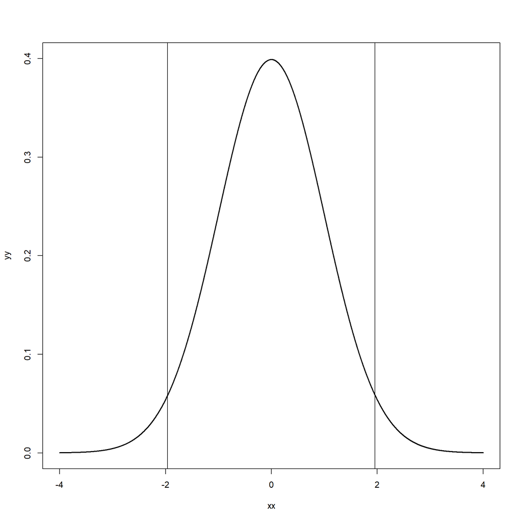

```r
view_crit_region <- function(alpha){

  # calculate the pdf over a range of values
  xx = seq(-4, +4, 0.001)
  yy = dnorm(xx)

  plot(xx, yy, lwd=2, type = "l", ylim = c(0,0.4))
  abline(v = qnorm(alpha / 2, mean = 0, sd = 1))
  abline(v = qnorm(1-alpha / 2, mean = 0, sd = 1))

  }
view_crit_region(0.05)
```

## Relation to Confidence Intervals

- It is interesting to examine the above acceptance region. Here, we accept $H_0$ if

$$\left|\frac{\overline{X}-\mu_0}{\sigma / \sqrt{n}} \right| \leq z_{\frac{\alpha}{2}}.$$

- We can rewrite the above condition as

$$\mu_0 \in \left[\overline{X}- z_{\frac{\alpha}{2}} \frac{\sigma}{\sqrt{n}} , \overline{X}+ z_{\frac{\alpha}{2}} \frac{\sigma}{\sqrt{n}}\right].$$

- The above interval is the $(1−\alpha)100\%$ confidence interval for $\mu_0$
- This is not a coincidence as there is a general relationship between confidence interval problems and hypothesis testing problems

# Hypothesis testing summary

## Test statistics and acceptance regions for a two-sided test of the mean

Two-sided hypothesis test for the mean $H_0: \mu=\mu_0, H_1: \mu\ne\mu_0$

| Case | Test Statistic | Acceptance Region |
| --- | --- | --- |
| $X_i \sim N(\mu, \sigma^2),\;\sigma$ known | $W=\frac{\overline{X}-\mu_0}{\sigma / \sqrt{n}}$ | $\vert W \vert \leq -z_{\frac{\alpha}{2}}$ |
| $n$ large, $X_i$ non-normal | $W=\frac{\overline{X}-\mu_0}{S / \sqrt{n}}$ | $\vert W \vert \leq -z_{\frac{\alpha}{2}}$ |
| $X_i \sim N(\mu, \sigma^2),\;\sigma$ unknown | $W=\frac{\overline{X}-\mu_0}{S / \sqrt{n}}$ | $\vert W \vert \leq -t_{\frac{\alpha}{2},n-1}$ |

## Test statistics and acceptance regions for a one-sided test of the mean

One-sided hypothesis test for the mean $H_0: \mu\leq\mu_0, H_1: \mu\gt\mu_0$

| Case | Test Statistic | Acceptance Region |
| --- | --- | --- |
| $X_i \sim N(\mu, \sigma^2),\;\sigma$ known | $W=\frac{\overline{X}-\mu_0}{\sigma / \sqrt{n}}$ | $W \leq -z_{\alpha}$ |
| $n$ large, $X_i$ non-normal | $W=\frac{\overline{X}-\mu_0}{S / \sqrt{n}}$ | $W \leq -z_{\alpha}$ |
| $X_i \sim N(\mu, \sigma^2),\;\sigma$ unknown | $W=\frac{\overline{X}-\mu_0}{S / \sqrt{n}}$ | $W \leq -t_{\alpha,n-1}$ |

[output not shown]

we can again repeat the above analysis and we obtain the acceptance regions reflected in the table below

| Case | Test Statistic | Acceptance Region |
| --- | --- | --- |
| $X_i \sim N(\mu, \sigma^2),\;\sigma$ known | $W=\frac{\overline{X}-\mu_0}{\sigma / \sqrt{n}}$ | $W \geq -z_{\alpha}$ |
| $n$ large, $X_i$ non-normal | $W=\frac{\overline{X}-\mu_0}{S / \sqrt{n}}$ | $W \geq -z_{\alpha}$ |
| $X_i \sim N(\mu, \sigma^2),\;\sigma$ unknown | $W=\frac{\overline{X}-\mu_0}{S / \sqrt{n}}$ | $W \geq -t_{\alpha,n-1}$ |